# Eric_Hirsch_607_Assigment_10

#### Word Clouds

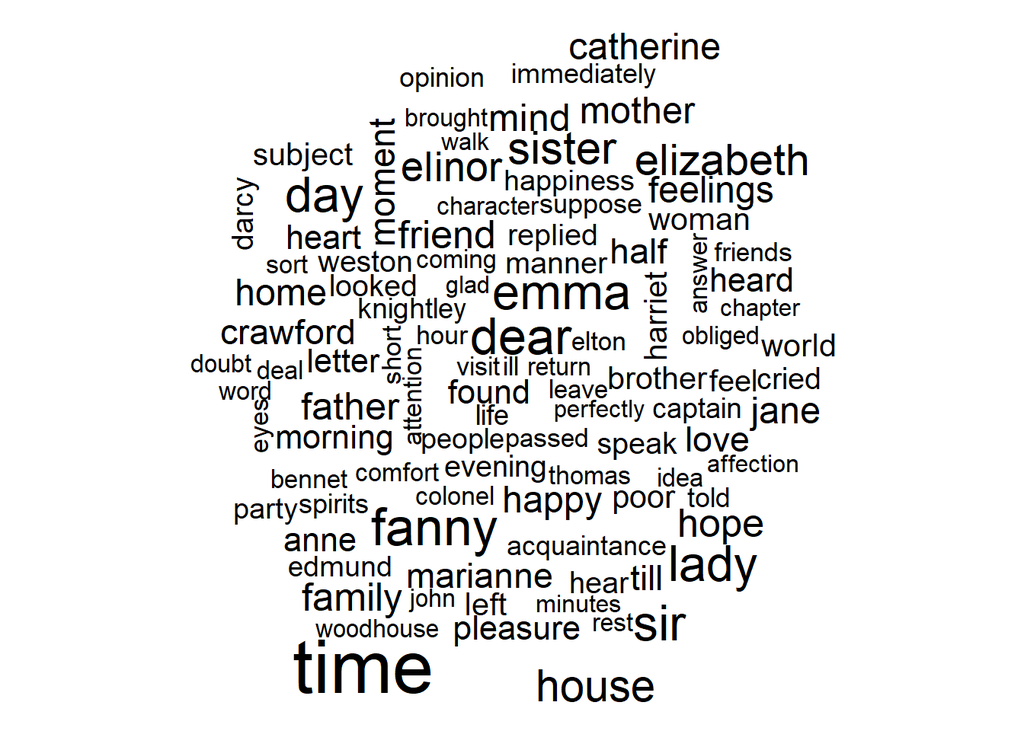

```r
tidy_books %>%
  anti_join(stop_words) %>%
  count(word) %>%
  with(wordcloud(word, n, max.words = 100))
```

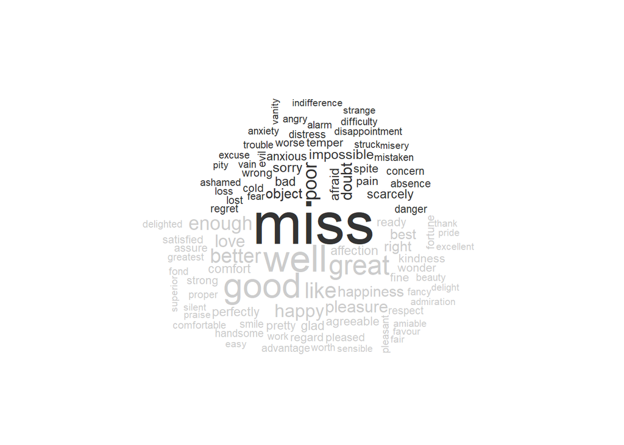

```r
tidy_books %>%
  inner_join(get_sentiments("bing")) %>%
  count(word, sentiment, sort = TRUE) %>%
  acast(word ~ sentiment, value.var = "n", fill = 0) %>%
  comparison.cloud(colors = c("gray20", "gray80"),
                   max.words = 100)
```

#### Looking at Units Beyond Just Words

```r
p_and_p_sentences <- tibble(text = prideprejudice) %>%
  unnest_tokens(sentence, text, token = "sentences")
p_and_p_sentences$sentence[2]
```

```
## [1] "by jane austen"
```

```r
austen_chapters <- austen_books() %>%
  group_by(book) %>%
  unnest_tokens(chapter, text, token = "regex",
                pattern = "Chapter|CHAPTER [\\dIVXLC]") %>%
  ungroup()

austen_chapters %>%
  group_by(book) %>%
  summarise(chapters = n())
```

```
## # A tibble: 6 x 2
##   book                chapters
##   <fct>                  <int>
## 1 Sense & Sensibility       51
## 2 Pride & Prejudice         62
## 3 Mansfield Park            49
## 4 Emma                      56
## 5 Northanger Abbey          32
## 6 Persuasion                25
```

#### We will use tidy text analysis to ask what are the most negative chapters in each of Jane Austen’s novels

1. Get the list of negative words from the Bing lexicon.
2. Make a data frame of how many words are in each chapter so we can normalize for the length of chapters.
3. Find the number of negative words in each chapter and divide by the total words in each chapter.

```r
bingnegative <- get_sentiments("bing") %>%
  filter(sentiment == "negative")

wordcounts <- tidy_books %>%
  group_by(book, chapter) %>%
  summarize(words = n())
tidy_books %>%
  semi_join(bingnegative) %>%
  group_by(book, chapter) %>%
  summarize(negativewords = n()) %>%
  left_join(wordcounts, by = c("book", "chapter")) %>%
  mutate(ratio = negativewords/words) %>%
  filter(chapter != 0) %>%
  slice_max(ratio, n = 1) %>%
  ungroup()
```

```
## # A tibble: 6 x 5
##   book                chapter negativewords words  ratio
##   <fct>                 <int>         <int> <int>  <dbl>
## 1 Sense & Sensibility      43           161  3405 0.0473
## 2 Pride & Prejudice        34           111  2104 0.0528
## 3 Mansfield Park           46           173  3685 0.0469
## 4 Emma                     15           151  3340 0.0452
## 5 Northanger Abbey         21           149  2982 0.0500
## 6 Persuasion                4            62  1807 0.0343
```

### Sentiment Analysis On Broadway

I am analyzing a dataset from kaggle (https://www.kaggle.com/jessemostipak/broadway-weekly-grosses) which has a table of synopses and a table of gross receipts for Broadway plays for the past several decades. I will use the package SentimentAnalysis, which contains 4 dictionaries: Harvard-IV, an all-purpose dictionary developed at Harvard, Henry’s finance specific dictionary, the Loughran-Macdonald dictionary (another finance dictionary), and the QDAP, which analyses discourse. Given the specific foci of the latter three databases, I expect the Harvard database to be the most useful.

The reason I am using the SentimentAnalysis package is that it operates differently from the tidytext library - it provides summary statistics for weighted scores using a complex algorithm (utilizing LASSO regularization) which considers not only a term within a discourse but its position. This may help us more reliably determine whether an observation is predominantly positive or negative.

```r
library(SentimentAnalysis)
dfGrosses<-read.csv("https://raw.githubusercontent.com/ericonsi/CUNY_607/main/Assigments/Assignment%2010/grosses.csv")
dfSynopses<-read.csv("https://raw.githubusercontent.com/ericonsi/CUNY_607/main/Assigments/Assignment%2010/synopses.csv", fileEncoding = "UTF-8-BOM")
```

#### We compare the performance of the 4 dictionaries on a simple pass-through of the play synopses:

```r
sentiment <- analyzeSentiment(dfSynopses$synopsis)

table(convertToBinaryResponse(sentiment$SentimentGI))
```

```
##
## negative positive
##      214      731
```

```r
summary(sentiment$SentimentGI)
```

```
##     Min.  1st Qu.   Median     Mean  3rd Qu.     Max.     NA's
## -0.36364  0.00000  0.06667  0.06235  0.13636  0.54545      177
```

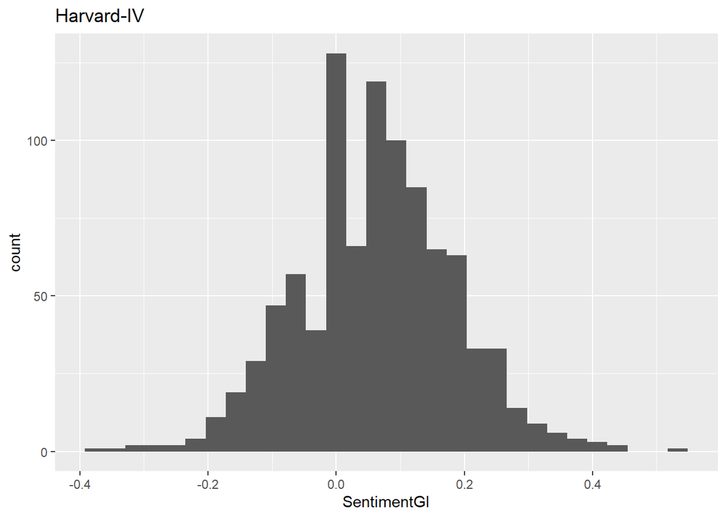

```r
ggplot(sentiment, aes(SentimentGI)) +
  geom_histogram() +
  ggtitle("Harvard-IV")
```

```r
table(convertToBinaryResponse(sentiment$SentimentGI))
```

```
##
## negative positive
##      214      731
```

```r
summary(sentiment$SentimentHE)
```

```
##     Min.  1st Qu.   Median     Mean  3rd Qu.     Max.     NA's
## -0.11765  0.00000  0.00000  0.00509  0.00000  0.20000      177
```

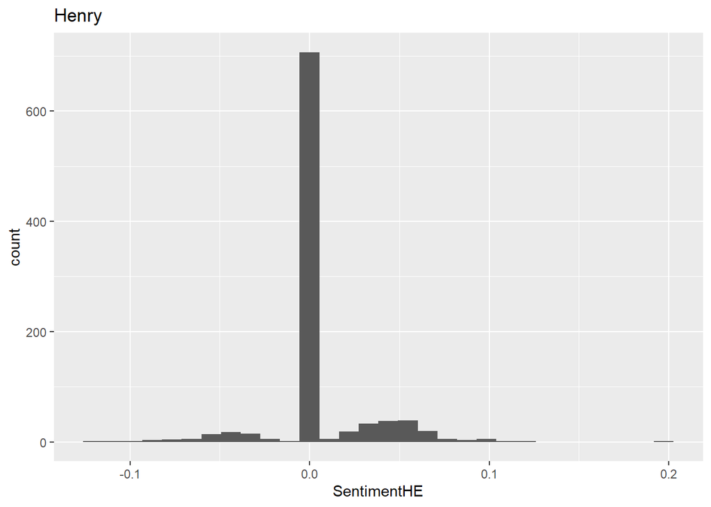

```r
ggplot(sentiment, aes(SentimentHE)) +
  geom_histogram() +
   ggtitle("Henry")
```

```r
table(convertToBinaryResponse(sentiment$SentimentGI))
```

```
##
## negative positive
##      214      731
```

```r
summary(sentiment$SentimentLM)
```

```
##     Min.  1st Qu.   Median     Mean  3rd Qu.     Max.     NA's
## -0.21053 -0.04545  0.00000 -0.01085  0.00000  0.23529      177
```

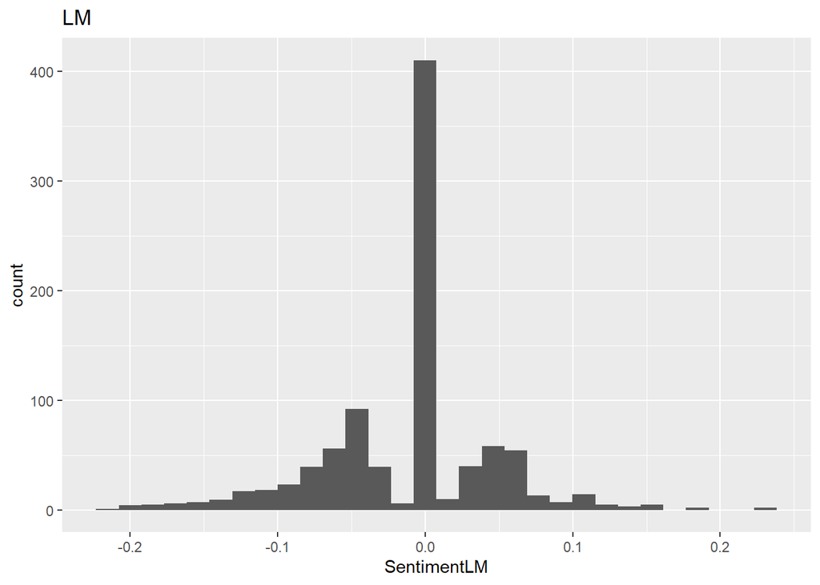

```r
ggplot(sentiment, aes(SentimentLM)) +
  geom_histogram() +
   ggtitle("LM")
```

```r
table(convertToBinaryResponse(sentiment$SentimentGI))
```

```
##
## negative positive
##      214      731
```

```r
summary(sentiment$SentimentQDAP)
```

```
##     Min.  1st Qu.   Median     Mean  3rd Qu.     Max.     NA's
## -0.45455 -0.04348  0.04348  0.03430  0.11111  0.37500      177
```

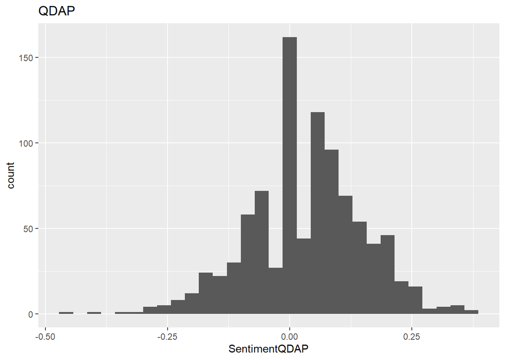

```r
ggplot(sentiment, aes(SentimentQDAP)) +
  geom_histogram() +
   ggtitle("QDAP")
```

Not surprisingly, in the finance dictionaries there are few matches between the dictionaries and words in the play synopses. The QDAP does better, and the Harvard analysis has the most matches. The QDAP analysis and the Harvard analysis are relatively similar in their distribution. They both find the plays, on average, to be mildly positive.

#### We compare the Harvard dictionary to the dictionaries we used from Tidytext.

```r
summary(DictionaryGI)
```

```
##          Length Class  Mode
## negative 2005   -none- character
## positive 1637   -none- character
```

```r
get_sentiments("nrc") %>%
  filter(sentiment %in% c("positive", "negative")) %>%
  count(sentiment)
```

```
## # A tibble: 2 x 2
##   sentiment     n
##   <chr>     <int>
## 1 negative   3324
## 2 positive   2312
```

```r
get_sentiments("bing") %>%
  count(sentiment)
```

```
## # A tibble: 2 x 2
##   sentiment     n
##   <chr>     <int>
## 1 negative   4781
## 2 positive   2005
```

The Harvard dictionary (DictionaryGI in the r code) has fewer words than the nrc and bing dictionaries. In addition, there is much more parity between positive and negative words in the Harvard dictionary than the others.

#### Using sentiment analysis to predict show success

Now that we have a simple tool for evaluating synopsis sentiment we can use it to do some analysis. For example, is there an association between play sentiment and gross revenue or seats sold?

The boxplots and scatterplots below suggest there is.

```r
dfSynopses2 <- cbind(dfSynopses, sentiment)

dfTotalSeats <- dfGrosses %>%
  group_by(show) %>%
  summarise(total_seats_sold  = sum(seats_sold), total_revenues = sum(weekly_gross))

dfJoin <- dfSynopses2 %>%
  inner_join(dfTotalSeats, by="show")

dfJoin <- na.omit(dfJoin)

dfSeatAnalysis <- dfJoin %>%
  filter(total_seats_sold<1000000) %>%
  filter(total_revenues>20000000) %>%
  mutate(Sentiment_Valence = case_when(SentimentGI > 0 ~ 'positive',
                           SentimentGI <=0 ~ 'neutral or negative'))
```

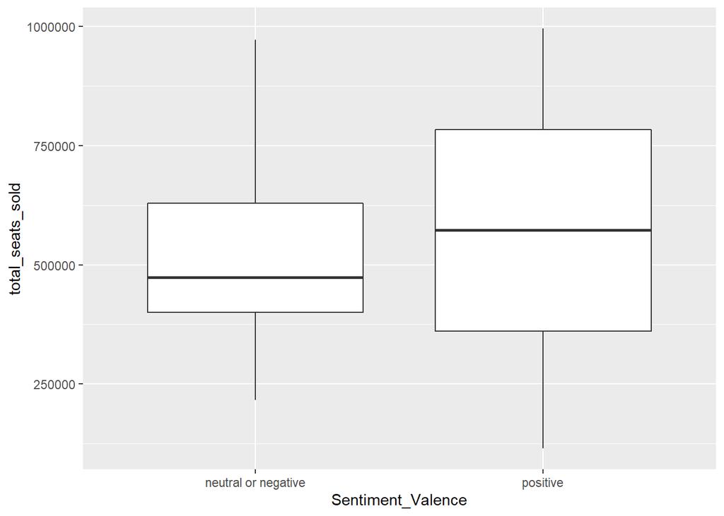

```r
ggplot(dfSeatAnalysis, aes(x =Sentiment_Valence, y=total_seats_sold)) +
  geom_boxplot()
```

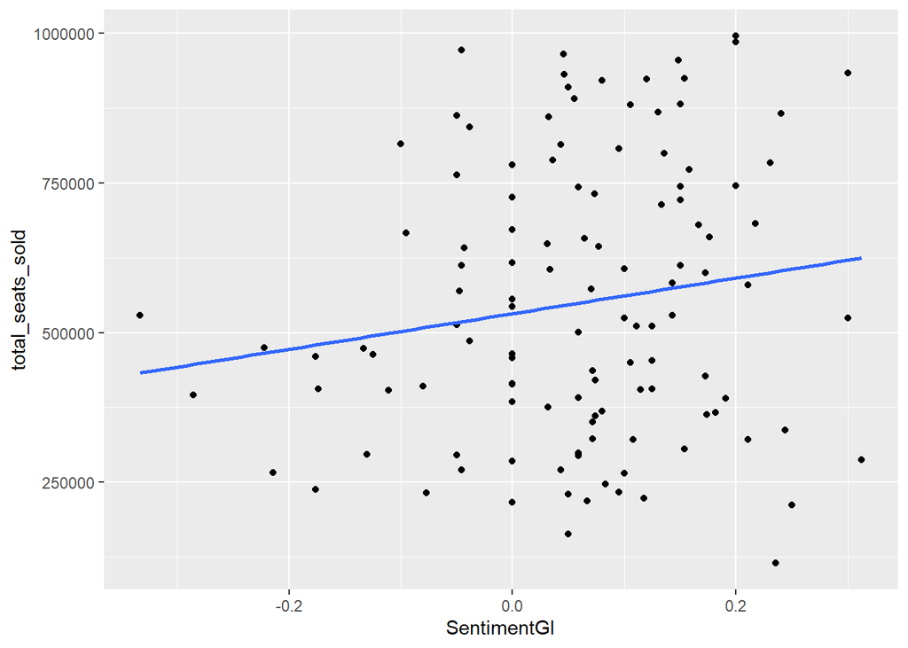

```r
ggplot(dfSeatAnalysis, aes(SentimentGI, total_seats_sold)) +
  geom_point() +
  stat_smooth(method = "lm", se = FALSE)
```

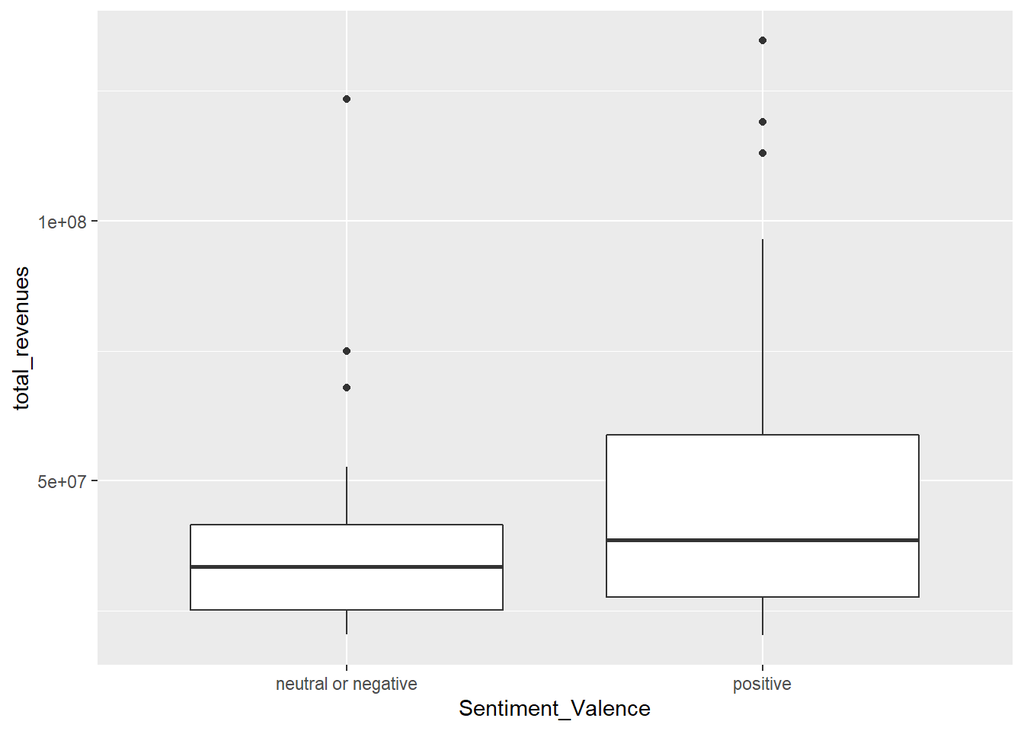

```r
ggplot(dfSeatAnalysis, aes(x =Sentiment_Valence, y=total_revenues)) +
  geom_boxplot()
```

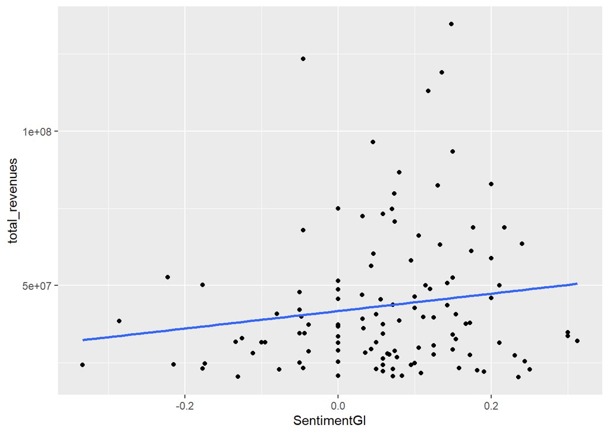

```r
ggplot(dfSeatAnalysis, aes(SentimentGI, total_revenues)) +
  geom_point() +
  stat_smooth(method = "lm", se = FALSE)
```

While the data remains suggestive that more positive shows do better, regression analysis fails to allow us to reject the possibility that the apparent association is due to sampling error (at a 95% confidence level.)

```r
m3 <- lm(total_seats_sold ~ SentimentGI, data = dfSeatAnalysis)
summary(m3)
```

```
##
## Call:
## lm(formula = total_seats_sold ~ SentimentGI, data = dfSeatAnalysis)
##
## Residuals:
##     Min      1Q  Median      3Q     Max
## -487533 -196771  -18893  179514  453624
##
## Coefficients:
##             Estimate Std. Error t value Pr(>|t|)
## (Intercept)   531794      23338  22.787   <2e-16 ***
## SentimentGI   297676     175827   1.693   0.0931 .
## ---
## Signif. codes:  0 '***' 0.001 '**' 0.01 '*' 0.05 '.' 0.1 ' ' 1
##
## Residual standard error: 229200 on 118 degrees of freedom
## Multiple R-squared:  0.02371,    Adjusted R-squared:  0.01544
## F-statistic: 2.866 on 1 and 118 DF,  p-value: 0.09309
```

```r
m <- lm(total_revenues ~ SentimentGI, data = dfSeatAnalysis)
summary(m)
```

```
##
## Call:
## lm(formula = total_revenues ~ SentimentGI, data = dfSeatAnalysis)
##
## Residuals:
##       Min        1Q    Median        3Q       Max
## -28122826 -16020108  -5858789   7159369  88739954
##
## Coefficients:
##             Estimate Std. Error t value Pr(>|t|)
## (Intercept) 41732283    2330535  17.907   <2e-16 ***
## SentimentGI 28257644   17558076   1.609     0.11
## ---
## Signif. codes:  0 '***' 0.001 '**' 0.01 '*' 0.05 '.' 0.1 ' ' 1
##
## Residual standard error: 22890000 on 118 degrees of freedom
## Multiple R-squared:  0.02148,    Adjusted R-squared:  0.01319
## F-statistic:  2.59 on 1 and 118 DF,  p-value: 0.1102
```

#### Comparing the Harvard results and the Bing results

Here we analyze the synopses dataset using Bing to see if it makes the same conclusions about the plays’ sentiment.

```r
tidy_x <- dfSynopses %>%
  unnest_tokens(word, synopsis)

bing_word_counts2 <- tidy_x %>%
  inner_join(get_sentiments("bing")) %>%
  count(word, sentiment, sort = TRUE) %>%
  ungroup()
x <- bing_word_counts2 %>%
  count(sentiment) %>%
  mutate(percentage = n / sum(n))
x
```

```
##   sentiment   n percentage
## 1  negative 622  0.6056475
## 2  positive 405  0.3943525
```

This word cloud helps us understand why:

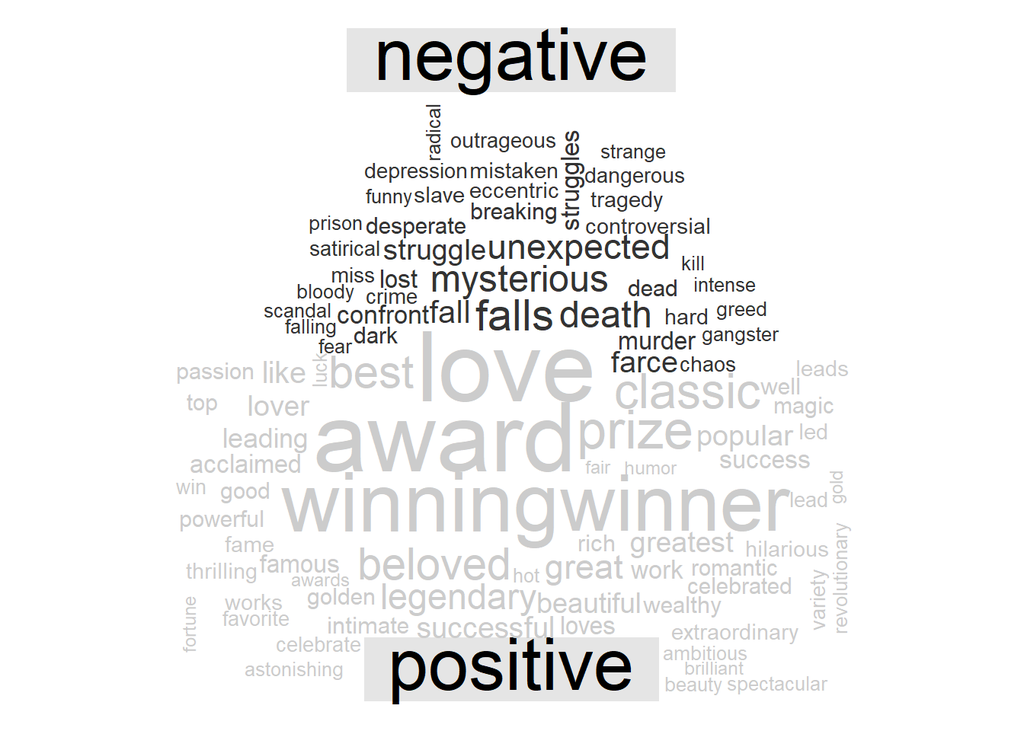

```r
tidy_x %>%
  inner_join(get_sentiments("bing")) %>%
  count(word, sentiment, sort = TRUE) %>%
  acast(word ~ sentiment, value.var = "n", fill = 0) %>%
  comparison.cloud(colors = c("gray20", "gray80"),
                   max.words = 100)
```

Consider this: A satirical farce about an eccentric millionaire who falls intensely in love with a mysterious stranger has 7 negative words and only one positive one. Even “funny” is considered negative here.

It does not help all that much to remove some of the words:

```r
bing_word_counts3 <- tidy_x %>%
  filter(word !="falls" & word !="fall" & word!="unexpected" & word!="mysterious" & word!="farce") %>%
  inner_join(get_sentiments("bing")) %>%
  count(word, sentiment, sort = TRUE) %>%
  ungroup()
x1 <- bing_word_counts3 %>%
  count(sentiment) %>%
  mutate(percentage = n / sum(n))
x1
```

```
##   sentiment   n percentage
## 1  negative 617  0.6037182
## 2  positive 405  0.3962818
```

#### Conclusion

Sentiment analysis is an interesting tool but has its limitations. As the Bing vs Harvard analysis shows, different dictionaries and algorithms can produce different results. As more context-specific dictionaries emerge, analyses will surely improve.